# Global Tourism Patterns and Visitor Behaviour in Dubai

## Figure 2 - Top 15 Countries

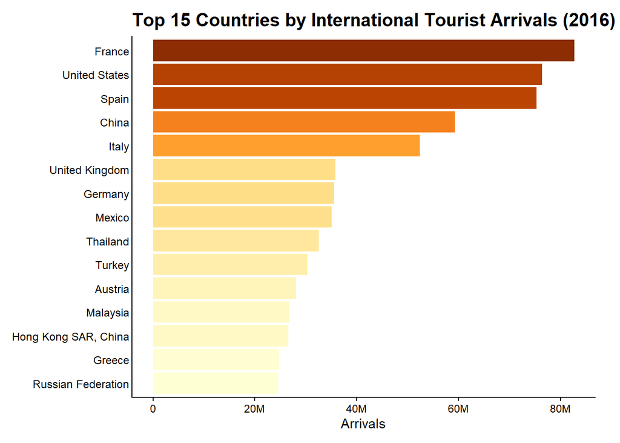

```r
# Remove World Bank aggregate and regional codes so only actual countries remain
aggregate_codes <- c(
  "WLD","HIC","OEC","PST","ECS","IDA","LMC","EUU","IBD","MIC",
  "EMU","UMC","LDC","EAP","EAR","LIC","SSF","SAS","MEA","NAC",
  "LAC","TSA","TSS","OSS","CSS","ARB","CEB","ECA","FCS","HPC",
  "IBT","IDX","INX","LTE","MNA","OED","PRE","PSS","SSA","SST",
  "TMN","TEC","TLA","AFE","AFW", "EAS","LCN","LMY","IDB","TEA","LMY"
)

top15_world <- world_2016 |>
  filter(!`Country Code` %in% aggregate_codes) |>
  slice_max(order_by = Arrivals, n = 15) |>
  mutate(`Country Name` = fct_reorder(`Country Name`, Arrivals))

ggplot(top15_world, aes(x = `Country Name`, y = Arrivals, fill = Arrivals)) +
  geom_col() +
  coord_flip() +
  scale_fill_distiller(
    palette = "YlOrBr",
    direction = 1,
    labels = label_number(scale_cut = cut_short_scale())
  ) +
  scale_y_continuous(labels = label_number(scale_cut = cut_short_scale())) +
  labs(
    title = "Top 15 Countries by International Tourist Arrivals (2016)",
    x = NULL,
    y = "Arrivals"
  ) +
  theme_classic() +
  theme(
    plot.title = element_text(face = "bold", size = 15),
    legend.position = "none",
    axis.text.y = element_text(size = 9),
    axis.ticks.y = element_blank(),
    plot.margin = margin(10, 20, 10, 10)
  )
```

This ranking plot confirms what the map suggested: France leads all individual countries by a clear margin, with Spain and the United States close behind. The gap between the top three and the rest of the list is substantial.

## Figure 3 - Arrivals Over Time

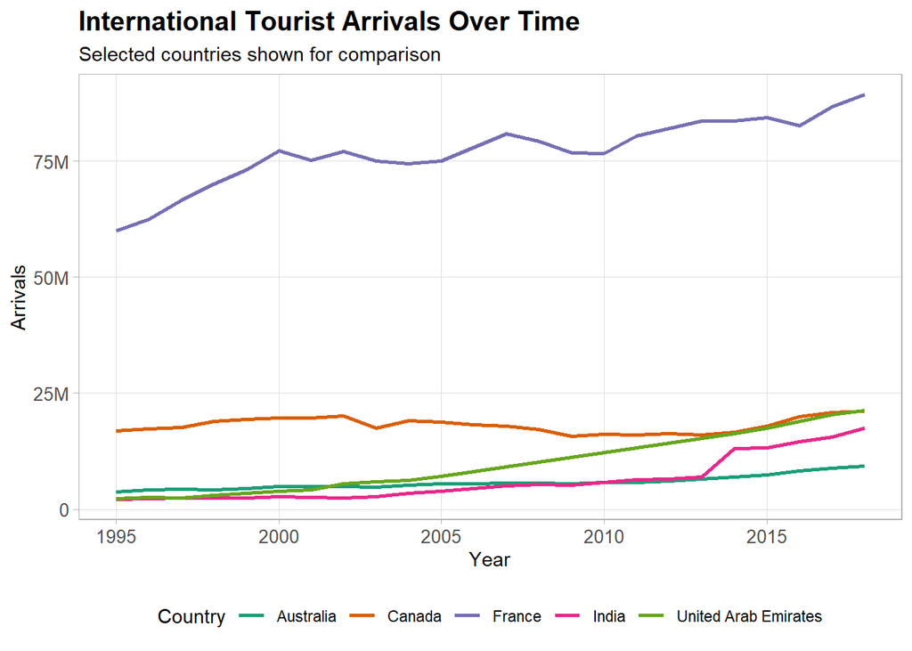

```r
selected_countries <- c("United Arab Emirates", "Canada", "France", "India", "Australia")

world_selected <- world_tidy |>
  filter(`Country Name` %in% selected_countries, !is.na(Arrivals))

ggplot(world_selected, aes(x = Year, y = Arrivals, colour = `Country Name`)) +
  geom_line(linewidth = 1) +
  scale_x_continuous(breaks = seq(1995, 2020, by = 5)) +
  scale_y_continuous(labels = label_number(scale_cut = cut_short_scale())) +
  scale_colour_brewer(palette = "Dark2") +
  labs(
    title = "International Tourist Arrivals Over Time",
    subtitle = "Selected countries shown for comparison",
    x = "Year",
    y = "Arrivals",
    colour = "Country"
  ) +
  theme_light() +
  theme(
    plot.title = element_text(face = "bold", size = 15),
    legend.position = "bottom",
    panel.grid.minor = element_blank(),
    axis.text = element_text(size = 10)
  )
```

France consistently leads in arrivals across the entire period shown. India and the UAE show the sharpest upward trends after 2010, suggesting rapid growth in inbound tourism during that period.

## Figure 4 - Sankey Style Plot of Travel Purpose and Accommodation

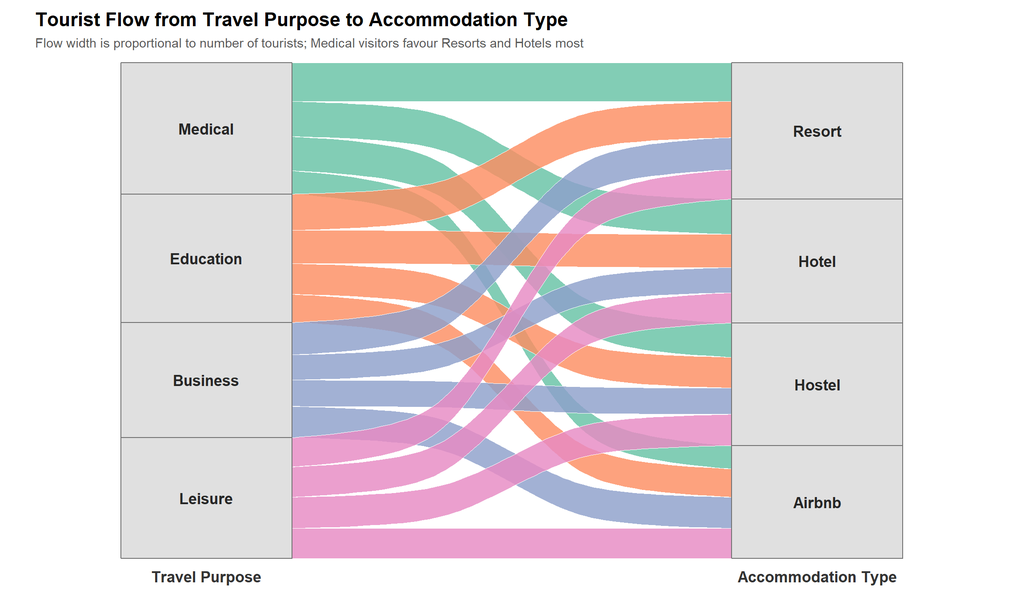

```r
sankey_data <- tourism |>
  count(Travel_Purpose, Accommodation_Type) |>
  mutate(
    Travel_Purpose = factor(
      Travel_Purpose,
      levels = c("Medical", "Education", "Business", "Leisure")
    ),
    Accommodation_Type = factor(
      Accommodation_Type,
      levels = c("Resort", "Hotel", "Hostel", "Airbnb")
    )
  )

ggplot(sankey_data,
       aes(axis1 = Travel_Purpose, axis2 = Accommodation_Type, y = n)) +
  geom_alluvium(
    aes(fill = Travel_Purpose),
    width     = 0.28,
    alpha     = 0.82,
    colour    = "white",
    linewidth = 0.3,
    knot.pos  = 0.38
  ) +
  geom_stratum(
    width     = 0.28,
    fill      = "grey88",
    colour    = "grey45",
    linewidth = 0.5
  ) +
  geom_text(
    stat     = "stratum",
    aes(label = after_stat(stratum)),
    size     = 4.5,
    fontface = "bold",
    colour   = "grey15"
  ) +
  scale_x_discrete(
    limits = c("Travel Purpose", "Accommodation Type"),
    expand = c(0.14, 0.14)
  ) +
  scale_fill_brewer(palette = "Set2") +
  scale_y_continuous(expand = expansion(mult = c(0.01, 0.01))) +
  labs(
    title    = "Tourist Flow from Travel Purpose to Accommodation Type",
    subtitle = "Flow width is proportional to number of tourists; Medical visitors favour Resorts and Hotels most",
    x        = NULL,
    y        = NULL
  ) +
  theme_minimal(base_size = 13) +
  theme(
    plot.title      = element_text(face = "bold", size = 16),
    plot.subtitle   = element_text(colour = "grey35", size = 11),
    panel.grid      = element_blank(),
    axis.text.x     = element_text(face = "bold", size = 13, colour = "grey20"),
    axis.text.y     = element_blank(),
    axis.ticks      = element_blank(),
    legend.position = "none",
    plot.margin     = margin(10, 30, 10, 30)
  )
```

This alluvial (Sankey-style) plot maps each travel purpose on the left to the accommodation type chosen on the right. Strata are ordered to reduce visual crossing — Medical travellers, who most strongly favour Resorts and Hotels, sit at the top of the left axis aligned with Resort and Hotel on the right. The width of each flowing band is proportional to the number of tourists.

## Figure 5 - Average Stay Duration by Tourist Origin

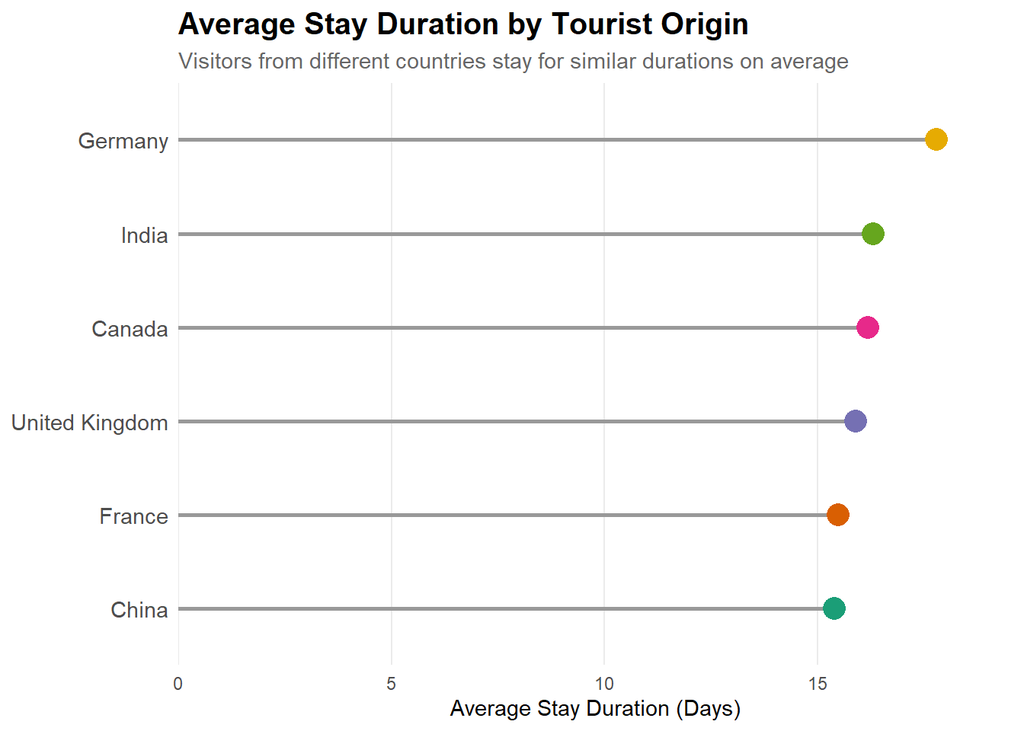

```r
tourism |>
  mutate(Country = forcats::fct_lump_n(Country, n = 6)) |>
  filter(Country != "Other") |>
  group_by(Country) |>
  summarise(Avg_Stay = mean(Stay_Duration_Days, na.rm = TRUE)) |>
  mutate(Country = fct_reorder(Country, Avg_Stay)) |>
  ggplot(aes(x = Country, y = Avg_Stay)) +
  geom_segment(aes(x = Country, xend = Country, y = 0, yend = Avg_Stay),
               colour = "grey60", linewidth = 1) +
  geom_point(aes(colour = Country), size = 5) +
  scale_colour_brewer(palette = "Dark2") +
  scale_y_continuous(expand = expansion(mult = c(0, 0.1))) +
  coord_flip() +
  labs(
    title    = "Average Stay Duration by Tourist Origin",
    subtitle = "Visitors from different countries stay for similar durations on average",
    x        = NULL,
    y        = "Average Stay Duration (Days)"
  ) +
  theme_minimal() +
  theme(
    plot.title         = element_text(face = "bold", size = 15),
    plot.subtitle      = element_text(colour = "grey40", size = 11),
    panel.grid.major.y = element_blank(),
    panel.grid.minor   = element_blank(),
    legend.position    = "none",
    axis.text.y        = element_text(size = 11)
  )
```

This lollipop chart compares average stay duration across the most common tourist origin countries. The averages are quite similar, suggesting that visitors from these countries tend to stay for roughly similar lengths of time.

## Figure 6 - Heatmap of Tourist Origin and Travel Purpose

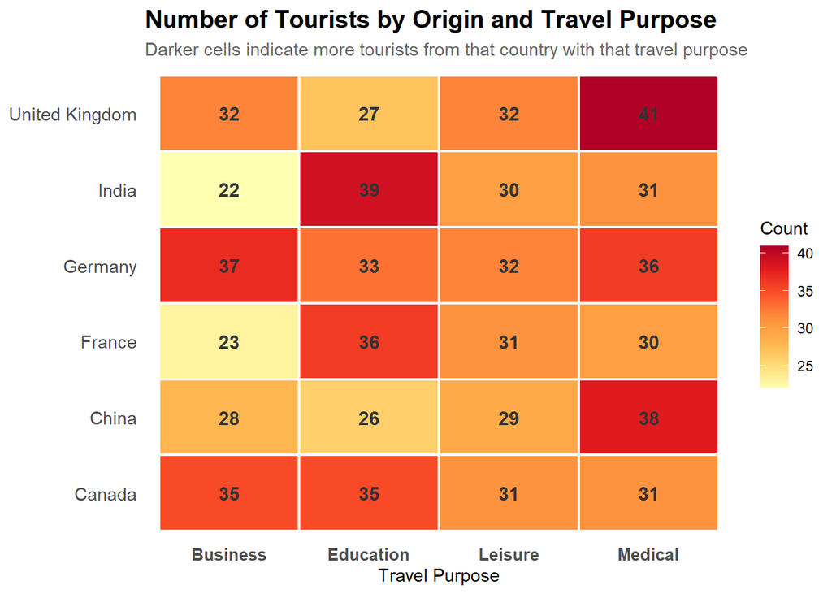

```r
tourism |>
  mutate(Country = forcats::fct_lump_n(Country, n = 6)) |>
  filter(Country != "Other") |>
  count(Country, Travel_Purpose) |>
  ggplot(aes(x = Travel_Purpose, y = Country, fill = n)) +
  geom_tile(colour = "white", linewidth = 0.8) +
  geom_text(aes(label = n), size = 4, fontface = "bold", colour = "grey20") +
  scale_fill_distiller(palette = "YlOrRd", direction = 1) +
  labs(
    title    = "Number of Tourists by Origin and Travel Purpose",
    subtitle = "Darker cells indicate more tourists from that country with that travel purpose",
    x        = "Travel Purpose",
    y        = NULL,
    fill     = "Count"
  ) +
  theme_minimal() +
  theme(
    plot.title         = element_text(face = "bold", size = 15),
    plot.subtitle      = element_text(colour = "grey40", size = 11),
    panel.grid         = element_blank(),
    axis.text.x        = element_text(size = 10, face = "bold"),
    axis.text.y        = element_text(size = 11),
    legend.position    = "right"
  )
```

This heatmap shows the number of tourists for each combination of country of origin and travel purpose. Darker cells indicate higher counts, making it easier to spot the strongest country-purpose combinations at a glance.

## Conclusion

Overall, the images demonstrate how tourism trends vary significantly between nations as well as within categories of traveler behavior. According to the global tourism dataset, foreign arrivals are concentrated in a limited number of nations, with France leading the way. Growth trends vary among nations, with areas like India and the United Arab Emirates exhibiting significant increases over time. The UAE tourism information reveals that the average stay duration is quite comparable among the major tourist origin nations, and that accommodation choices vary significantly by travel purpose. Additionally, the heatmap demonstrates that rather than being dominated by a single distinct pattern, tourist origin and travel purpose combinations are dispersed throughout multiple categories. Together, these graphics demonstrate that tourism can be studied both geographically and behaviourally, and that using multiple visualisation types gives a clearer picture of the topic.

## References

- World Bank tourism arrivals dataset: https://data.worldbank.org/indicator/ST.INT.ARVL
- Dubai tourism behaviour dataset (Kaggle): https://www.kaggle.com/datasets/muhamamdumeraliriaz/tourism-behavior-analysis-in-uae
- Natural Earth world map data: https://www.naturalearthdata.com/
- https://www.kaggle.com/datasets/ayushggarg/international-tourism-demographics

## AI Prompts

- Show me how to build a choropleth map in R using sf and ggplot2.
- Help me turn a wide country-year dataset into tidy long format using pivot_longer.
- Show me how to make an alluvial plot in R using ggalluvial.
- Help me improve my ggplot scales and themes for a tourism report.
- Help me examine these tourism datasets by identifying important variables, suggesting useful comparisons, and pointing out data cleaning steps before I build my visualisations.